# Modeling_ver3_Rmd

## 0. Library

```r
# Base library
library(dplyr)
library(tidyverse)
```

```r
library(ggplot2)

# Confusion Matrix
library(caret)
# ROC curve
library(ROCR)

# model library
library(rpart)
library(rpart.plot)
library(randomForest)
# plot combine
library(gridExtra)
```

## 1. Data load

```r
breast_cancer <- read.csv("../data/breast_cancer.csv", header=T)

# NULL Data인 X열 제외
breast_cancer <- breast_cancer %>% select(-X)

# 'diagnosis'를 factor 로 변환
breast_cancer$diagnosis <- as.factor(breast_cancer$diagnosis)

# 속성 확인
str(breast_cancer)
```

```
## 'data.frame':    569 obs. of  32 variables:
##  $ id                     : int  842302 842517 84300903 84348301 84358402 843786 844359 84458202 844981 84501001 ...
##  $ diagnosis              : Factor w/ 2 levels "B","M": 2 2 2 2 2 2 2 2 2 2 ...
##  $ radius_mean            : num  18 20.6 19.7 11.4 20.3 ...
##  $ texture_mean           : num  10.4 17.8 21.2 20.4 14.3 ...
##  $ perimeter_mean         : num  122.8 132.9 130 77.6 135.1 ...
##  $ area_mean              : num  1001 1326 1203 386 1297 ...
##  $ smoothness_mean        : num  0.1184 0.0847 0.1096 0.1425 0.1003 ...
##  $ compactness_mean       : num  0.2776 0.0786 0.1599 0.2839 0.1328 ...
##  $ concavity_mean         : num  0.3001 0.0869 0.1974 0.2414 0.198 ...
##  $ concave.points_mean    : num  0.1471 0.0702 0.1279 0.1052 0.1043 ...
##  $ symmetry_mean          : num  0.242 0.181 0.207 0.26 0.181 ...
##  $ fractal_dimension_mean : num  0.0787 0.0567 0.06 0.0974 0.0588 ...
##  $ radius_se              : num  1.095 0.543 0.746 0.496 0.757 ...
##  $ texture_se             : num  0.905 0.734 0.787 1.156 0.781 ...
```

[output cut: 18 more lines]

이 데이터는 유방암 진단에 관련된 정보로 각 변수는 다음과 같은 의미

- id: 환자의 ID
- diagnosis: 진단 결과 (M = 악성, B = 양성)
- radius_mean: 암세포의 평균 반경
- texture_mean: 암세포의 평균 질감
- perimeter_mean: 암세포의 평균 둘레
- area_mean: 암세포의 평균 면적
- smoothness_mean: 암세포의 평균 매끄러움
- compactness_mean: 암세포의 평균 조그만함
- concavity_mean: 암세포의 평균 오목함
- concave.points_mean: 암세포의 평균 오목한 점의 수
- symmetry_mean: 암세포의 평균 대칭성
- fractal_dimension_mean: 암세포의 평균 프랙탈 차원

이외에도 각 특징의 표준 오차(_se)와 최악의 경우(_worst)에 대한 측정치가 포함

#### 데이터 분할

- train.index : 전채 데이터 중 70%를 샘플링한 train index
- breast_cancer.train: train data
- breast_cancer.val : valid data

```r
# seed 고정
set.seed(1226)

# 전체 데이터의 행 수
total_rows <- nrow(breast_cancer)

# 고정된 인덱스 생성
fixed_index <- sample(1:total_rows)

# train과 val의 비율을 7:3으로 설정
train_ratio <- 0.7
train_rows <- round(total_rows * train_ratio)

# 고정된 인덱스에서 train 데이터의 인덱스 선택
train.index <- fixed_index[1:train_rows]

# train과 val 데이터로 나누기
breast_cancer.train <- breast_cancer[train.index, ]
breast_cancer.val <- breast_cancer[-train.index, ]

train_count <- nrow(breast_cancer.train)
test_count <- nrow(breast_cancer.val)

cat("train data: ", train_count, "\n", "valid data: ", test_count, "\n")
```

```
## train data:  398
##  valid data:  171
```

여기까지는 약식으로 EDA 부분에서 처리할 내용을 작성한 내용으로 향후 EDA 에서 처리하는 과정으로 대체할 예정

이후부터가 Modeling 본 내용

## 2. Modeling

formula에 *diagnosis ~ 선택한 독립변수들* 의 형태로 저장

EDA를 통해 선택한 독립변수들을 아래 코드에서 확인 및 수정가능

```r
formula <- diagnosis ~ radius_mean + texture_mean + perimeter_mean + area_mean + smoothness_mean + compactness_mean + concavity_mean + concave.points_mean + symmetry_mean + fractal_dimension_mean
```

*Logistic regresion*, *DecisionTree*, *RandomForest* 3가지 모델에 대해서 성능 비교 진행

```r
# 모델 학습
logit_cancer <- glm(formula, data=breast_cancer.train, family=binomial())
tree_cancer <- rpart(formula, data=breast_cancer.train, method = "class")
rf_cancer <- randomForest(formula, data=breast_cancer.train, mtry=3, ntree=6)
```

### Compare Accuracy

각 모델에 대해서 첫번째로 Accuracy(정확도)를 비교를 진행하였습니다.

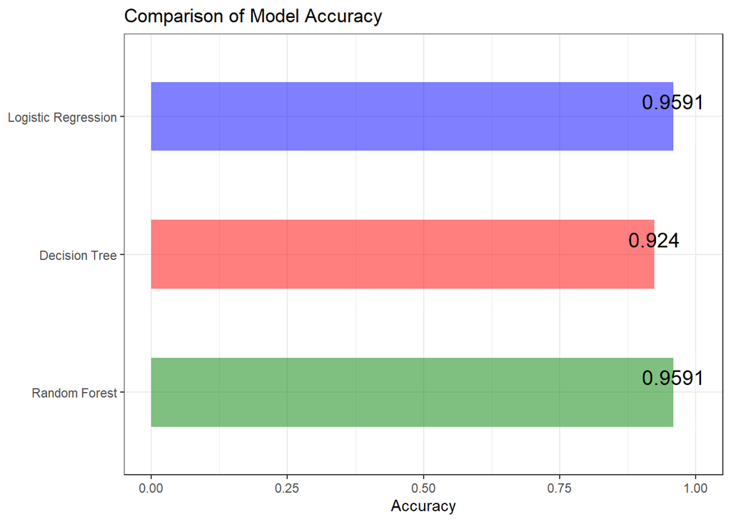

```r
# 각 모델에 대한 예측 생성
logit_pred_acc <- predict(logit_cancer, newdata = breast_cancer.val, type = "response")
tree_pred_acc <- predict(tree_cancer, newdata = breast_cancer.val, type = "class")
rf_pred_acc <- predict(rf_cancer, newdata = breast_cancer.val)

# 예측을 이진 클래스로 변환
logit_pred_class <- ifelse(logit_pred_acc > 0.5, "M", "B")

# 정확도 계산
logit_acc <- mean(logit_pred_class == breast_cancer.val$diagnosis)
tree_acc <- mean(tree_pred_acc == breast_cancer.val$diagnosis)
rf_acc <- mean(rf_pred_acc == breast_cancer.val$diagnosis)

# 정확도를 데이터 프레임으로 변환
acc_df <- data.frame(Model = c("Logistic Regression", "Decision Tree", "Random Forest"),
                     Accuracy = c(logit_acc, tree_acc, rf_acc))

# Model 변수를 팩터로 변환하고 레벨 순서를 지정합니다
acc_df$Model <- factor(acc_df$Model, levels=c("Random Forest", "Decision Tree", "Logistic Regression"))

# 색상을 벡터로 저장합니다
colors <- c("#0000FF80", "#FF000080", "#00800080")

# 바 플롯을 그립니다
ggplot(acc_df, aes(x=Model, y=Accuracy, fill=Model)) +
  geom_bar(stat="identity", width=0.5, fill=colors) +
  ylim(0, 1) +
  geom_text(aes(label=round(Accuracy, 4)), size=5, vjust=-0.5) +
  coord_flip() +
  labs(title="Comparison of Model Accuracy", x="Model", y="Accuracy") +
  theme_bw() +
  theme(legend.position="none", axis.title.y=element_blank())
```

### Compare ROC & AUC

다음으로는 Roc 곡선을 시각화 하고 각 모델별 AUC를 비교를 진행하였습니다.

ROC Curve

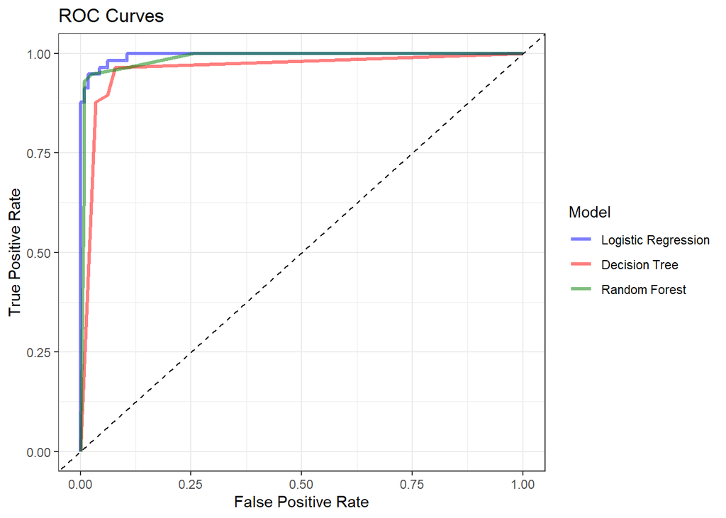

```r
# 각 모델에 대한 예측 생성
logit_pred_roc <- predict(logit_cancer, newdata = breast_cancer.val, type = "response")
tree_pred_roc <- predict(tree_cancer, newdata = breast_cancer.val, type = "prob")[,2]
rf_pred_roc <- predict(rf_cancer, newdata = breast_cancer.val, type = "prob")[,2]

# 예측 결과와 실제 레이블을 사용하여 예측 객체를 생성합니다
pred_logit <- prediction(logit_pred_roc, breast_cancer.val$diagnosis)
pred_tree <- prediction(tree_pred_roc, breast_cancer.val$diagnosis)
pred_rf <- prediction(rf_pred_roc, breast_cancer.val$diagnosis)

# ROC 곡선을 계산합니다
perf_logit <- performance(pred_logit, "tpr", "fpr")
perf_tree <- performance(pred_tree, "tpr", "fpr")
perf_rf <- performance(pred_rf, "tpr", "fpr")

# 데이터 프레임을 생성합니다
df <- data.frame(
  TPR = c(perf_logit@y.values[[1]], perf_tree@y.values[[1]], perf_rf@y.values[[1]]),
  FPR = c(perf_logit@x.values[[1]], perf_tree@x.values[[1]], perf_rf@x.values[[1]]),
  Model = c(rep("Logistic Regression", length(perf_logit@y.values[[1]])),
            rep("Decision Tree", length(perf_tree@y.values[[1]])),
            rep("Random Forest", length(perf_rf@y.values[[1]])))
)

# ROC 곡선을 그립니다
ggplot(df, aes(x=FPR, y=TPR, color=Model)) +
  geom_line(size=1.2) +
  geom_abline(intercept = 0, slope = 1, linetype = "dashed") +
  labs(title="ROC Curves", x="False Positive Rate", y="True Positive Rate") +
  theme_bw() +
  scale_color_manual(values=c("#0000FF80", "#FF000080", "#00800080"),
                     breaks=c("Logistic Regression", "Decision Tree", "Random Forest"))
```

ROC Curve를 보았을때 Decison Tree < Random Forest = Logistic Regression 정도를

대략적으로 파악할수 있고 AUC 값을 통해 수치적으로 정확하게 다시 확인하였습니다.

AUC

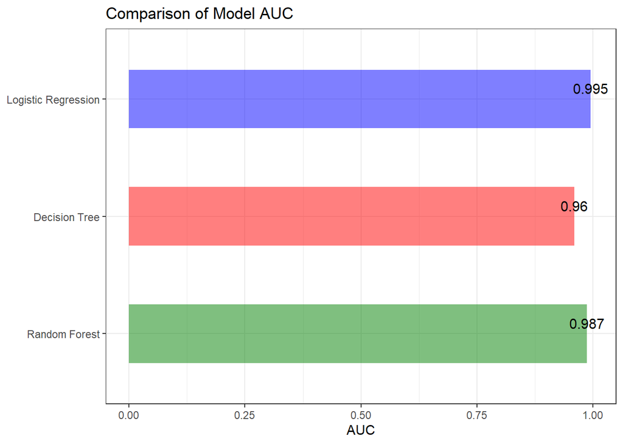

```r
# AUC를 계산합니다
auc_logit <- performance(pred_logit, "auc")@y.values[[1]]
auc_tree <- performance(pred_tree, "auc")@y.values[[1]]
auc_rf <- performance(pred_rf, "auc")@y.values[[1]]

# AUC를 데이터 프레임으로 변환합니다
auc_df <- data.frame(Model = c("Logistic Regression", "Decision Tree", "Random Forest"),
                     AUC = c(auc_logit, auc_tree, auc_rf))

# Model 변수를 팩터로 변환하고 레벨 순서를 지정합니다
auc_df$Model <- factor(auc_df$Model, levels=c("Random Forest", "Decision Tree", "Logistic Regression"))

# 색상을 벡터로 저장합니다
colors <- c("#0000FF80", "#FF000080", "#00800080")

# 바 플롯을 그립니다
ggplot(auc_df, aes(x=Model, y=AUC, fill=Model)) +
  geom_bar(stat="identity", width=0.5, fill=colors) +
  geom_text(aes(label=round(AUC, 3)), size=4, vjust=-0.5) +
  ylim(0, 1) +
  coord_flip() +
  labs(title="Comparison of Model AUC", x="Model", y="AUC") +
  theme_bw() +
  theme(legend.position="none", axis.title.y=element_blank())
```

각 모델에 대해서 AUC 를 구하고 시각화를 하였을때 Decison Tree < Random Forest < Logistic Regression 순으로

AUC 의 성능이 보이고 있습니다.

### Compare KS Statistic

마지막 성능 비교로 KS Statistic 를 비교하는 과정을 진행

```r
# 각 모델에 대한 예측 생성
logit_pred_ks <- predict(logit_cancer, newdata = breast_cancer.val, type = "response")
tree_pred_ks <- predict(tree_cancer, newdata = breast_cancer.val, type = "prob")[,2]
rf_pred_ks <- predict(rf_cancer, newdata = breast_cancer.val, type = "prob")[,2]

# '양성'과 '악성' 진단 결과에 대한 예측 확률을 분리합니다
logit_pred_B <- logit_pred_ks[breast_cancer.val$diagnosis == "B"]
logit_pred_M <- logit_pred_ks[breast_cancer.val$diagnosis == "M"]

tree_pred_B <- tree_pred_ks[breast_cancer.val$diagnosis == "B"]
tree_pred_M <- tree_pred_ks[breast_cancer.val$diagnosis == "M"]

rf_pred_B <- rf_pred_ks[breast_cancer.val$diagnosis == "B"]
rf_pred_M <- rf_pred_ks[breast_cancer.val$diagnosis == "M"]

# 각 모델의 KS 통계량을 계산합니다
ks_logit <- ks.test(logit_pred_B, logit_pred_M)$statistic
ks_tree <- ks.test(tree_pred_B, tree_pred_M)$statistic
ks_rf <- ks.test(rf_pred_B, rf_pred_M)$statistic
```

각 모델별 진단결과에 대한 누적분포를 그래프로 시각화 작업

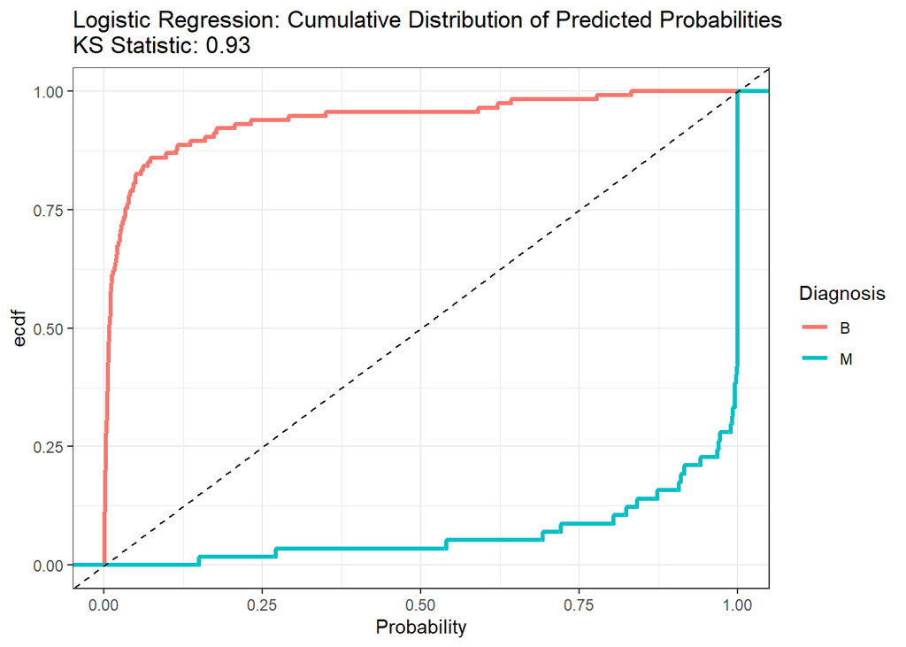

```r
# Logistic Regression 모델의 그래프
df_logit_B <- data.frame(Diagnosis = rep("B", length(logit_pred_B)), Probability = logit_pred_B)
df_logit_M <- data.frame(Diagnosis = rep("M", length(logit_pred_M)), Probability = logit_pred_M)
df_logit <- rbind(df_logit_B, df_logit_M)

ggplot(df_logit, aes(x=Probability, color=Diagnosis)) +
  stat_ecdf(geom = "step", size=1.2) +
  geom_abline(intercept = 0, slope = 1, linetype = "dashed") +
  labs(title=paste("Logistic Regression: Cumulative Distribution of Predicted Probabilities\nKS Statistic:", round(ks_logit, 3))) +
  theme_bw()
```

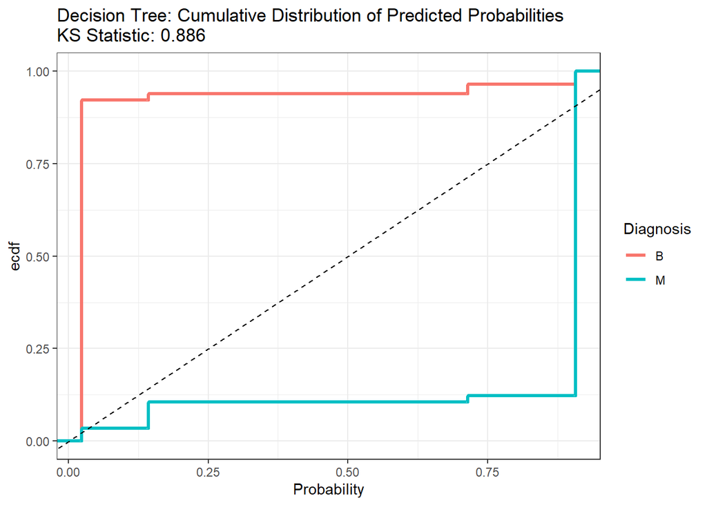

```r
# Decision Tree 모델의 그래프
df_tree_B <- data.frame(Diagnosis = rep("B", length(tree_pred_B)), Probability = tree_pred_B)
df_tree_M <- data.frame(Diagnosis = rep("M", length(tree_pred_M)), Probability = tree_pred_M)
df_tree <- rbind(df_tree_B, df_tree_M)

ggplot(df_tree, aes(x=Probability, color=Diagnosis)) +
  stat_ecdf(geom = "step", size=1.2) +
  geom_abline(intercept = 0, slope = 1, linetype = "dashed") +
  labs(title=paste("Decision Tree: Cumulative Distribution of Predicted Probabilities\nKS Statistic:", round(ks_tree, 3))) +
  theme_bw()
```

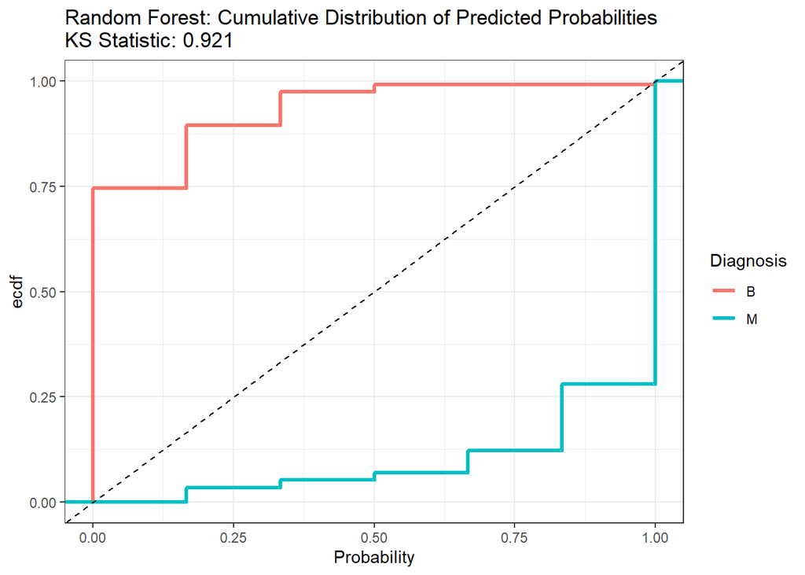

```r
# Random Forest 모델의 그래프
df_rf_B <- data.frame(Diagnosis = rep("B", length(rf_pred_B)), Probability = rf_pred_B)
df_rf_M <- data.frame(Diagnosis = rep("M", length(rf_pred_M)), Probability = rf_pred_M)
df_rf <- rbind(df_rf_B, df_rf_M)

ggplot(df_rf, aes(x=Probability, color=Diagnosis)) +
  stat_ecdf(geom = "step", size=1.2) +
  geom_abline(intercept = 0, slope = 1, linetype = "dashed") +
  labs(title=paste("Random Forest: Cumulative Distribution of Predicted Probabilities\nKS Statistic:", round(ks_rf, 3))) +
  theme_bw()
```

<그래프에 대한 부연 설명>

1. ‘양성’과 ‘악성’ 진단 결과에 대한 예측 확률을 분리
2. 이를 사용하여 각각의 누적분포(ECDF)를 계산
3. 누적분포를 시각화하여 각 예측 확률 값이나 그보다 낮은 값이 관찰될 누적 확률을 보여줌

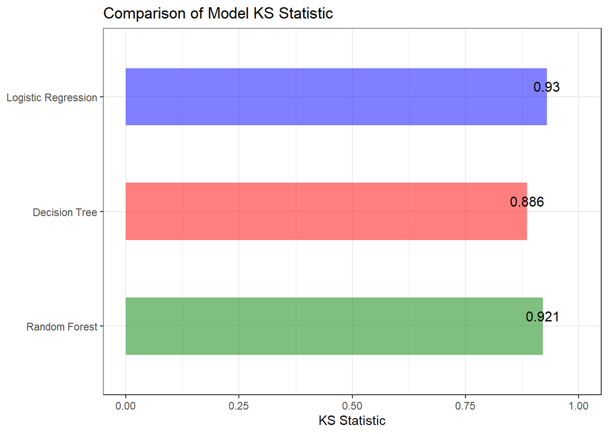

```r
# KS 통계량을 데이터 프레임으로 만듭니다
ks_df <- data.frame(Model = c("Logistic Regression", "Decision Tree", "Random Forest"),
                    KS = c(ks_logit, ks_tree, ks_rf))

# Model 변수를 팩터로 변환하고 레벨 순서를 지정합니다
ks_df$Model <- factor(ks_df$Model, levels=c("Random Forest", "Decision Tree", "Logistic Regression"))

# 바 플롯을 그립니다
ggplot(ks_df, aes(x=Model, y=KS, fill=Model)) +
  geom_bar(stat="identity", width=0.5, fill=colors) +
  ylim(0, 1) +
  geom_text(aes(label=round(KS, 3)), size=4, vjust=-0.5) +
  coord_flip() +
  labs(title="Comparison of Model KS Statistic", x="Model", y="KS Statistic") +
  theme_bw() +
  theme(legend.position="none", axis.title.y=element_blank())
```

KS Statistic을 보았을때 Decison Tree < Random Forest < Logistic Regression 순으로

KS Statistic 의 수치값을 보이고 있는데 이때 KS 통계량이 클수록 두 분포 사이의 차이가 크다는 것을 의미

따라서, Decison Tree < Random Forest < Logistic Regression 순으로

‘양성’과 ‘악성’ 진단 결과에 대한 예측 확률의 분포를 가장 잘 구별한다고 해석할수 있습니다.

### Compare All

*Logistic Regresion, Decision Tree, Random Forest* 에 대해서 *Accuracy, AUC, KS Statistic* 을 비교하였는데

이러한 성능 비교를 한 그래프 내에서 비교하는 과정을 진행하였습니다.

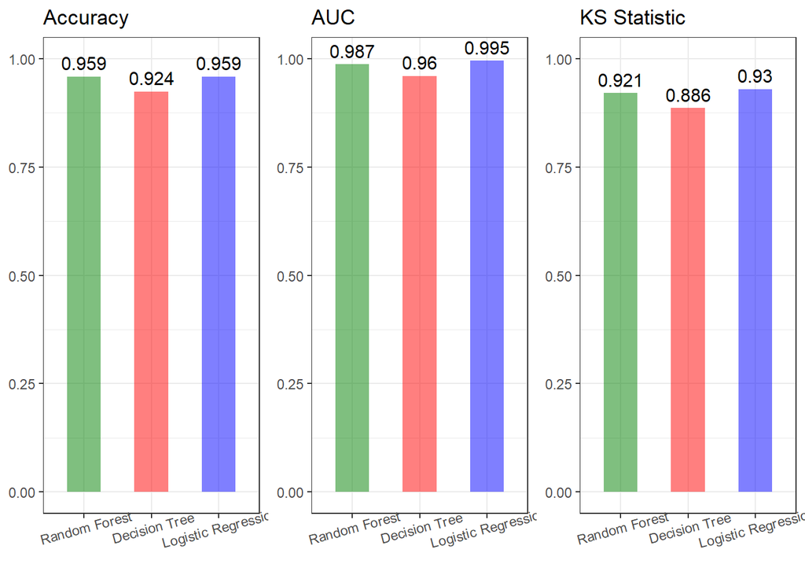

```r
# 필요한 라이브러리를 불러옵니다
library(gridExtra)

# 각각의 그래프를 생성합니다
p1 <- ggplot(acc_df, aes(x=Accuracy, y=Model, fill=Model)) +
  geom_bar(stat="identity", width=0.5, fill=colors) +
  geom_text(aes(label=round(Accuracy, 3)), size=4, vjust=-0.5) +
  coord_flip() +
  xlim(0, 1) +
  labs(title="Accuracy") +
  theme_bw() +
  theme(legend.position="none", axis.title.x=element_blank(), axis.title.y=element_blank(), axis.text.x = element_text(angle = 15))

p2 <- ggplot(auc_df, aes(x=AUC, y=Model, fill=Model)) +
  geom_bar(stat="identity", width=0.5, fill=colors) +
  geom_text(aes(label=round(AUC, 3)), size=4, vjust=-0.5) +
  coord_flip() +
  xlim(0, 1) +
  labs(title="AUC") +
  theme_bw() +
  theme(legend.position="none", axis.title.x=element_blank(), axis.title.y=element_blank(), axis.text.x = element_text(angle = 15))

p3 <- ggplot(ks_df, aes(x=KS, y=Model, fill=Model)) +
  geom_bar(stat="identity", width=0.5, fill=colors) +
  geom_text(aes(label=round(KS, 3)), size=4, vjust=-0.5) +
  coord_flip() +
  xlim(0, 1) +
  labs(title="KS Statistic") +
  theme_bw() +
  theme(legend.position="none", axis.title.x=element_blank(), axis.title.y=element_blank(), axis.text.x = element_text(angle = 15))

# 3개의 그래프를 하나의 그래프로 표현합니다
grid.arrange(p1, p2, p3, nrow=1)
```

*Logistic Regresion*, *Decision Tree*, *Random Forest* 3가지 모델에 대해서 성능 비교를 진행하였을때

전반적으로 *Logistic Regresion* 모델이 다른 모델에 비해 안정적으로 좋은 성능을 보이고 있어

*Logistic Regresion* 모델을 이용하여 평점표 모형을 개발하도록 구상하였습니다.

## 향후 추가 내용

*Logistic Regresion* 을 통해 평점표 개발하는 코드 작성 계획중..